# Yichun Chen MSBA 320 Final project using Python

### Yichun Chen MSBA Final Project: Facebook ads analysis

- dataset source (downloaded from Kaggle): https://www.kaggle.com/datasets/loveall/clicks-conversion-tracking
- In descriptic analysis, I explore which age group, gender, and interest group can generate more conversions, so that the company can target these groups when placing marketing ads on Facebook in future. I also do a correlation analysis of the numeric variables
- In inferencial analysis, I try to find an adequate model to explain the data.
- Dependent variable: 'Conversions': number of people who actually purchased the product.
- Explanatory variables:
  - 'Impressions': number of times the ads were shown to facebook users.
  - 'Clicks': number of people who clicked on the ad.
  - 'Spent': amount of money spent on the ad

## Part 1 : load dataset, and check data types and structures

```python
import numpy as np
import pandas as pd
import matplotlib.pyplot as plt
import seaborn as sns
import statsmodels.api as sm
import statsmodels.formula.api as smf
from statsmodels.formula.api import ols
```

```python
# load data set:
df = pd.read_csv('KAG_conversion_data.csv',dtype={'ad_id': object, 'xyz_campaign_id': object,
    'fb_campaign_id': object, 'interest': object}) # change first 4 columns's data type from integer to object
```

```python
df.head()
```

|  | ad_id | xyz_campaign_id | fb_campaign_id | age | gender | interest | Impressions | Clicks | Spent | Total_Conversion | Approved_Conversion |
| --- | --- | --- | --- | --- | --- | --- | --- | --- | --- | --- | --- |
| 0 | 708746 | 916 | 103916 | 30-34 | M | 15 | 7350 | 1 | 1.43 | 2 | 1 |
| 1 | 708749 | 916 | 103917 | 30-34 | M | 16 | 17861 | 2 | 1.82 | 2 | 0 |
| 2 | 708771 | 916 | 103920 | 30-34 | M | 20 | 693 | 0 | 0.00 | 1 | 0 |
| 3 | 708815 | 916 | 103928 | 30-34 | M | 28 | 4259 | 1 | 1.25 | 1 | 0 |
| 4 | 708818 | 916 | 103928 | 30-34 | M | 28 | 4133 | 1 | 1.29 | 1 | 1 |

```python
# check data structure and data types
df.info()
```

```
<class 'pandas.core.frame.DataFrame'>
RangeIndex: 1143 entries, 0 to 1142
Data columns (total 11 columns):
 #   Column               Non-Null Count  Dtype
---  ------               --------------  -----
 0   ad_id                1143 non-null   object
 1   xyz_campaign_id      1143 non-null   object
 2   fb_campaign_id       1143 non-null   object
 3   age                  1143 non-null   object
 4   gender               1143 non-null   object
 5   interest             1143 non-null   object
 6   Impressions          1143 non-null   int64
 7   Clicks               1143 non-null   int64
 8   Spent                1143 non-null   float64
 9   Total_Conversion     1143 non-null   int64
 10  Approved_Conversion  1143 non-null   int64
dtypes: float64(1), int64(4), object(6)
memory usage: 98.4+ KB
```

```python
# statistical summary of numeric columns:
df.describe()
```

|  | Impressions | Clicks | Spent | Total_Conversion | Approved_Conversion |
| --- | --- | --- | --- | --- | --- |
| count | 1.143000e+03 | 1143.000000 | 1143.000000 | 1143.000000 | 1143.000000 |
| mean | 1.867321e+05 | 33.390201 | 51.360656 | 2.855643 | 0.944007 |
| std | 3.127622e+05 | 56.892438 | 86.908418 | 4.483593 | 1.737708 |
| min | 8.700000e+01 | 0.000000 | 0.000000 | 0.000000 | 0.000000 |
| 25% | 6.503500e+03 | 1.000000 | 1.480000 | 1.000000 | 0.000000 |
| 50% | 5.150900e+04 | 8.000000 | 12.370000 | 1.000000 | 1.000000 |
| 75% | 2.217690e+05 | 37.500000 | 60.025000 | 3.000000 | 1.000000 |
| max | 3.052003e+06 | 421.000000 | 639.949998 | 60.000000 | 21.000000 |

```python
# check for missing values:
df.isna().sum()  # no missing value.
```

```
ad_id                  0
xyz_campaign_id        0
fb_campaign_id         0
age                    0
gender                 0
interest               0
Impressions            0
Clicks                 0
Spent                  0
Total_Conversion       0
Approved_Conversion    0
dtype: int64
```

```python
# check for unique values of each column:
df.nunique()
```

```
ad_id                  1143
xyz_campaign_id           3
fb_campaign_id          691
age                       4
gender                    2
interest                 40
Impressions            1130
Clicks                  183
Spent                   869
Total_Conversion         32
Approved_Conversion      16
dtype: int64
```

## Part 2 : Data pre-processing

```python
# delete columns that we don't need:  'fb_campaign_id','total_conversion'
df.drop(columns=['fb_campaign_id','Total_Conversion'],inplace=True)
```

```python
# rename column name:
df.rename(columns={'xyz_campaign_id': 'campaign_id','Approved_Conversion': 'Conversions'},inplace=True)

# check column names
df.columns
```

```
Index(['ad_id', 'campaign_id', 'age', 'gender', 'interest', 'Impressions',
       'Clicks', 'Spent', 'Conversions'],
      dtype='object')
```

```python
# for a better understanding, change campaign ID from number form to Letter presentation
campdict={'916':'Campaign A','936':'Campaign B','1178':'Campaign C'}
df['campaign_id'] = df['campaign_id'].map(campdict)
```

```python
df
```

[output not shown]

## Part 3 : Descriptive Statistics and Correlation Analysis

```python
# re-check data structure and data types:
df.info()
```

```
<class 'pandas.core.frame.DataFrame'>
RangeIndex: 1143 entries, 0 to 1142
Data columns (total 9 columns):
 #   Column       Non-Null Count  Dtype
---  ------       --------------  -----
 0   ad_id        1143 non-null   object
 1   campaign_id  1143 non-null   object
 2   age          1143 non-null   object
 3   gender       1143 non-null   object
 4   interest     1143 non-null   object
 5   Impressions  1143 non-null   int64
 6   Clicks       1143 non-null   int64
 7   Spent        1143 non-null   float64
 8   Conversions  1143 non-null   int64
dtypes: float64(1), int64(3), object(5)
memory usage: 80.5+ KB
```

```python
# re-check statistical summary:
df.describe()
```

|  | Impressions | Clicks | Spent | Conversions |
| --- | --- | --- | --- | --- |
| count | 1.143000e+03 | 1143.000000 | 1143.000000 | 1143.000000 |
| mean | 1.867321e+05 | 33.390201 | 51.360656 | 0.944007 |
| std | 3.127622e+05 | 56.892438 | 86.908418 | 1.737708 |
| min | 8.700000e+01 | 0.000000 | 0.000000 | 0.000000 |
| 25% | 6.503500e+03 | 1.000000 | 1.480000 | 0.000000 |
| 50% | 5.150900e+04 | 8.000000 | 12.370000 | 1.000000 |
| 75% | 2.217690e+05 | 37.500000 | 60.025000 | 1.000000 |
| max | 3.052003e+06 | 421.000000 | 639.949998 | 21.000000 |

### univariate plots:

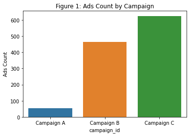

```python
sns.countplot(data=df, x='campaign_id')
plt.title('Figure 1: Ads Count by Campaign')
plt.ylabel('Ads Count')
```

#### results show campaign A has much fewer ads (only 54) run as compared to Capaign B and C.

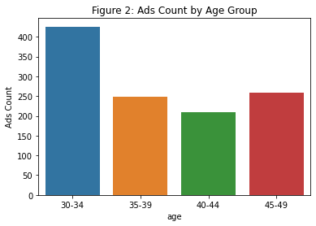

```python
sns.countplot(data=df,x='age')
plt.ylabel('Ads Count')
plt.title('Figure 2: Ads Count by Age Group')
```

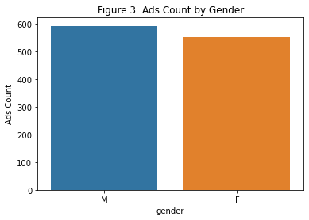

```python
sns.countplot(data=df,x='gender')
plt.ylabel('Ads Count')
plt.title('Figure 3: Ads Count by Gender')
```

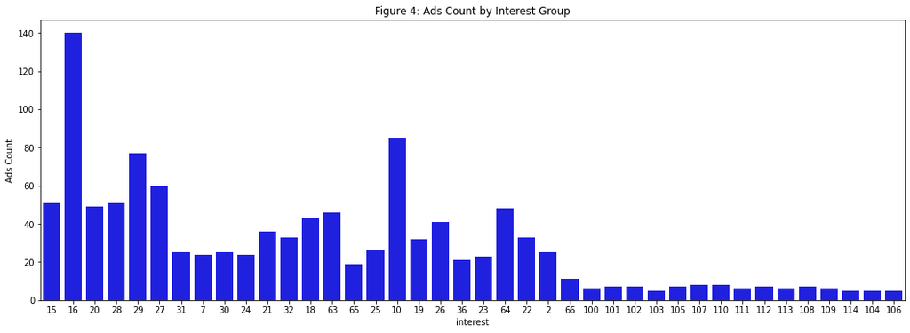

```python
# interest:
plt.figure(figsize=(18,6))
sns.countplot(x='interest',data=df,color='blue')
plt.ylabel('Ads Count')
plt.title('Figure 4: Ads Count by Interest Group')
```

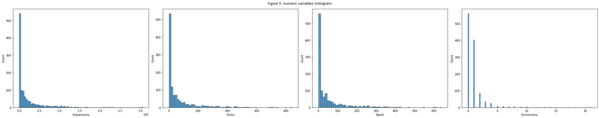

```python
# numeric variables distribution:
plt.figure(figsize = [30,6])

cols = ['Impressions','Clicks', 'Spent', 'Conversions']
for i in range(4):
    plt.subplot(1,4,i+1)
    sns.histplot(data=df,x=cols[i])


plt.suptitle('Figure 5: numeric variables histogram',fontsize=12)
plt.tight_layout()
```

### Bivariate and multivariate plots: explore age and/or gender's impact on conversion

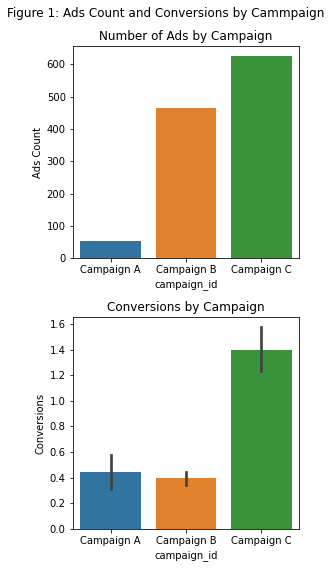

```python
plt.figure(figsize=(4,8))

# check Ads count by campaign
plt.subplot(211)
sns.countplot(data=df, x='campaign_id')
plt.title('Number of Ads by Campaign')
plt.ylabel('Ads Count')

# check relationship between campagin and conversions:
plt.subplot(212)
sns.barplot(data=df, x='campaign_id', y= 'Conversions')
plt.title('Conversions by Campaign')

plt.suptitle('Figure 1: Ads Count and Conversions by Cammpaign')
plt.tight_layout()
```

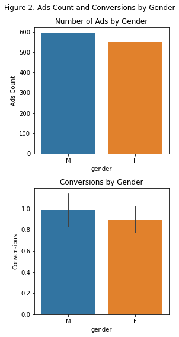

```python
plt.figure(figsize=(4,8))

# check Ads count by gender:
plt.subplot(211)
sns.countplot(data=df,x='gender')
plt.title('Number of Ads by Gender')
plt.ylabel('Ads Count')

# check relationship between gender and conversions:
plt.subplot(212)
sns.barplot(data=df, x='gender', y= 'Conversions')
plt.title('Conversions by Gender')

plt.suptitle('Figure 2: Ads Count and Conversions by Gender')
plt.tight_layout()
```

#### Findings: Men has slightly more conversions than women

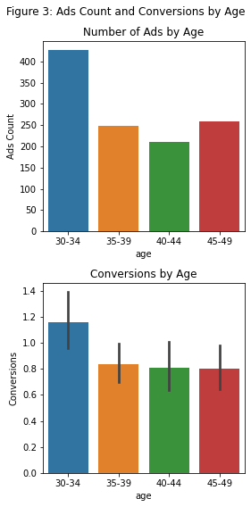

```python
plt.figure(figsize=(4,8))

# check Ads count by age:
plt.subplot(211)
sns.countplot(data=df,x='age')
plt.title('Number of Ads by Age')
plt.ylabel('Ads Count')


# check relationship between age and conversions:
plt.subplot(212)
sns.barplot(data=df, x='age', y= 'Conversions')
plt.title('Conversions by Age')

plt.suptitle('Figure 3: Ads Count and Conversions by Age')
plt.tight_layout()
```

#### Findings: Age group [30-34] have more conversions than other age groups.

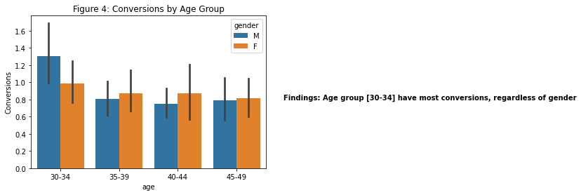

```python
# check relationship between gender, age and conversions:
sns.barplot(data=df, x='age', y= 'Conversions',hue='gender')
plt.title('Figure 4: Conversions by Age Group')
plt.text(3.8, 0.8, "Findings: Age group [30-34] have most conversions, regardless of gender", weight='semibold')
```

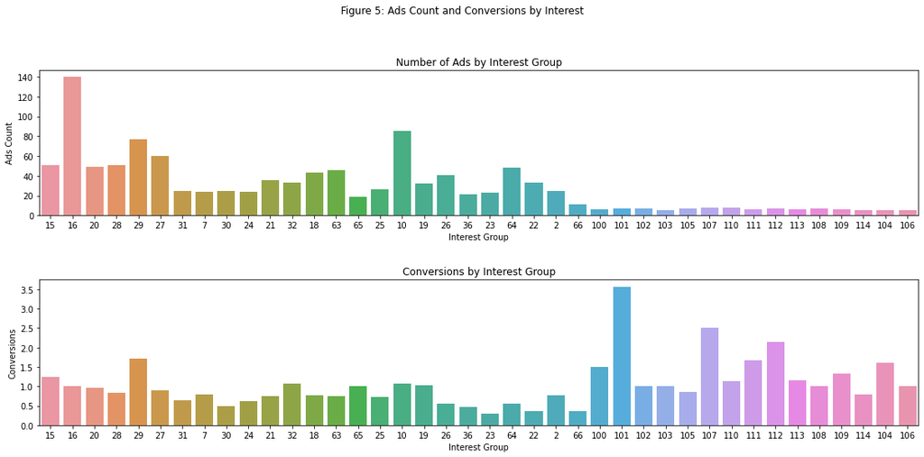

```python
plt.figure(figsize=(16,8))

# Gender distribution:
plt.subplot(211)
sns.countplot(data=df,x='interest')
plt.title('Number of Ads by Interest Group')
plt.xlabel('Interest Group')
plt.ylabel('Ads Count')

# check relationship between gender and conversion:
plt.subplot(212)
sns.barplot(data=df, x='interest', y= 'Conversions',ci=False)
plt.title('Conversions by Interest Group')
plt.xlabel('Interest Group')

plt.suptitle('Figure 5: Ads Count and Conversions by Interest')
plt.tight_layout(pad=3)
```

#### Findings:

It seems that the ads were targeted to the wrong interests groups. For example, many ads were displayed to people in interest[16],[27]and [10] , but these two interest groups' conversions were not as high as the less targeted groups: [100],[101],[104], [107] and [112].

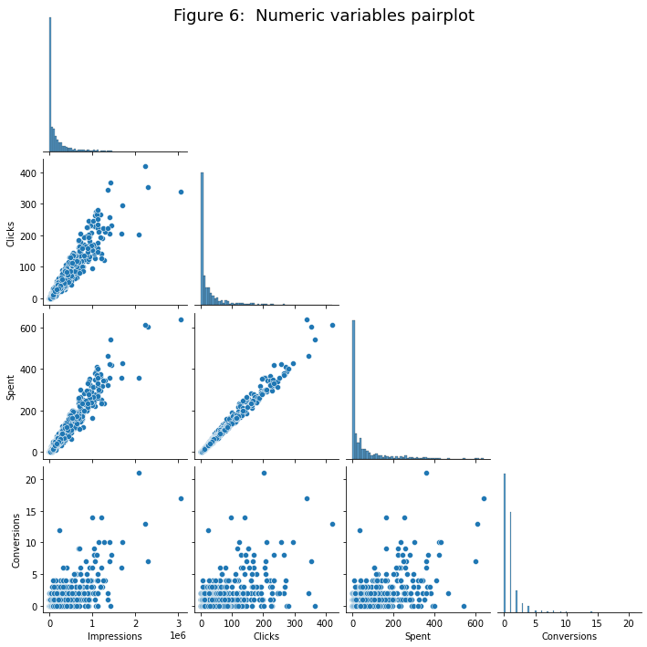

```python
# pair plot to check correlation between numeric variables:
sns.pairplot(data=df[['Impressions','Clicks','Spent','Conversions']],corner=True)
plt.suptitle('Figure 6:  Numeric variables pairplot',fontsize=18)
```

#### The pairplot shows:

- There seems to be a positive linear relationship between converions (the dependent variable) and the explanatory variables: Impressions, Clicks and Spent

### Correlation analysis

```python
# get correlation coefficients:
df[['Impressions','Clicks', 'Spent', 'Conversions']].corr()
```

|  | Impressions | Clicks | Spent | Conversions |
| --- | --- | --- | --- | --- |
| Impressions | 1.000000 | 0.948514 | 0.970386 | 0.684249 |
| Clicks | 0.948514 | 1.000000 | 0.992906 | 0.559526 |
| Spent | 0.970386 | 0.992906 | 1.000000 | 0.593178 |
| Conversions | 0.684249 | 0.559526 | 0.593178 | 1.000000 |

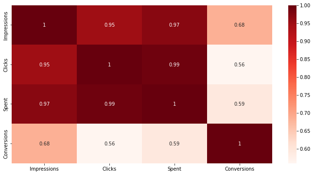

```python
# create a heatmap to visualize the correlations:
plt.figure(figsize=(12,6))
sns.heatmap(df.corr(),annot=True,cmap='Reds')
plt.title('Figure 7: Correlation Heatmap')
```

#### Part 3 conclusion:

- Age group [30-34] have more conversions than other age groups, regardless of gender.
- Many ads were displayed to people in interest group [16],[27]and [10] , but these two interest groups' conversions were not as high as the less targeted groups: [100],[101],[104], [107] and [112].
- Correlation analysis and pairplot suggested a positive linear relationship between converions (the dependent variable) and the explanatory variables: Impressions, Clicks and Spent

## Part 4: Inferential analysis:

```python
# model1: only 1 explanatory variable - 'Impressions'
model1 = smf.ols("Conversions ~ Impressions",data=df).fit()

# print model summary:
print(model1.summary())
```

```
                            OLS Regression Results
==============================================================================
Dep. Variable:            Conversions   R-squared:                       0.468
Model:                            OLS   Adj. R-squared:                  0.468
Method:                 Least Squares   F-statistic:                     1005.
Date:                Thu, 14 Apr 2022   Prob (F-statistic):          1.20e-158
Time:                        14:44:00   Log-Likelihood:                -1892.0
No. Observations:                1143   AIC:                             3788.
Df Residuals:                    1141   BIC:                             3798.
Df Model:                           1
Covariance Type:            nonrobust
===============================================================================
                  coef    std err          t      P>|t|      [0.025      0.975]
-------------------------------------------------------------------------------
Intercept       0.2341      0.044      5.360      0.000       0.148       0.320
Impressions  3.802e-06    1.2e-07     31.694      0.000    3.57e-06    4.04e-06
==============================================================================
Omnibus:                      764.040   Durbin-Watson:                   1.652
Prob(Omnibus):                  0.000   Jarque-Bera (JB):            24134.578
Skew:                           2.604   Prob(JB):                         0.00
Kurtosis:                      24.901   Cond. No.                     4.24e+05
==============================================================================

Notes:
[1] Standard Errors assume that the covariance matrix of the errors is correctly specified.
[2] The condition number is large, 4.24e+05. This might indicate that there are
strong multicollinearity or other numerical problems.
```

```python
# model2: only 1 explanatory variable - 'Clicks'
model2 = smf.ols("Conversions ~ Clicks",data=df).fit()

# print model summary:
print(model2.summary())
```

```
                            OLS Regression Results
==============================================================================
Dep. Variable:            Conversions   R-squared:                       0.313
Model:                            OLS   Adj. R-squared:                  0.312
Method:                 Least Squares   F-statistic:                     520.0
Date:                Thu, 14 Apr 2022   Prob (F-statistic):           3.83e-95
Time:                        14:44:59   Log-Likelihood:                -2038.3
No. Observations:                1143   AIC:                             4081.
Df Residuals:                    1141   BIC:                             4091.
Df Model:                           1
Covariance Type:            nonrobust
==============================================================================
                 coef    std err          t      P>|t|      [0.025      0.975]
------------------------------------------------------------------------------
Intercept      0.3734      0.049      7.555      0.000       0.276       0.470
Clicks         0.0171      0.001     22.804      0.000       0.016       0.019
==============================================================================
Omnibus:                      994.402   Durbin-Watson:                   1.556
Prob(Omnibus):                  0.000   Jarque-Bera (JB):            54487.619
Skew:                           3.700   Prob(JB):                         0.00
Kurtosis:                      36.005   Cond. No.                         76.5
==============================================================================

Notes:
[1] Standard Errors assume that the covariance matrix of the errors is correctly specified.
```

```python
# model3: only 1 explanatory variable - 'Spent'
model3 = smf.ols("Conversions ~ Spent",data=df).fit()

# print model summary:
print(model3.summary())
```

```
                            OLS Regression Results
==============================================================================
Dep. Variable:            Conversions   R-squared:                       0.352
Model:                            OLS   Adj. R-squared:                  0.351
Method:                 Least Squares   F-statistic:                     619.4
Date:                Thu, 14 Apr 2022   Prob (F-statistic):          1.43e-109
Time:                        14:45:42   Log-Likelihood:                -2005.1
No. Observations:                1143   AIC:                             4014.
Df Residuals:                    1141   BIC:                             4024.
Df Model:                           1
Covariance Type:            nonrobust
==============================================================================
                 coef    std err          t      P>|t|      [0.025      0.975]
------------------------------------------------------------------------------
Intercept      0.3348      0.048      6.963      0.000       0.240       0.429
Spent          0.0119      0.000     24.888      0.000       0.011       0.013
==============================================================================
Omnibus:                      944.823   Durbin-Watson:                   1.574
Prob(Omnibus):                  0.000   Jarque-Bera (JB):            47342.827
Skew:                           3.435   Prob(JB):                         0.00
Kurtosis:                      33.771   Cond. No.                         117.
==============================================================================

Notes:
[1] Standard Errors assume that the covariance matrix of the errors is correctly specified.
```

```python
# model4: 3 explanatory variables - 'Impressions', 'Clicks' and 'Spent'
model4 = smf.ols("Conversions ~ Impressions + Clicks + Spent",data=df).fit()

# print model summary:
print(model4.summary())
```

```
                            OLS Regression Results
==============================================================================
Dep. Variable:            Conversions   R-squared:                       0.554
Model:                            OLS   Adj. R-squared:                  0.553
Method:                 Least Squares   F-statistic:                     472.3
Date:                Thu, 14 Apr 2022   Prob (F-statistic):          2.54e-199
Time:                        14:47:29   Log-Likelihood:                -1791.0
No. Observations:                1143   AIC:                             3590.
Df Residuals:                    1139   BIC:                             3610.
Df Model:                           3
Covariance Type:            nonrobust
===============================================================================
                  coef    std err          t      P>|t|      [0.025      0.975]
-------------------------------------------------------------------------------
Intercept       0.2602      0.040      6.487      0.000       0.182       0.339
Impressions  1.013e-05   5.33e-07     18.994      0.000    9.08e-06    1.12e-05
Clicks         -0.0046      0.006     -0.767      0.443      -0.016       0.007
Spent          -0.0205      0.005     -4.019      0.000      -0.031      -0.011
==============================================================================
Omnibus:                      618.514   Durbin-Watson:                   1.789
Prob(Omnibus):                  0.000   Jarque-Bera (JB):            10307.265
Skew:                           2.112   Prob(JB):                         0.00
Kurtosis:                      17.092   Cond. No.                     4.25e+05
==============================================================================

Notes:
[1] Standard Errors assume that the covariance matrix of the errors is correctly specified.
[2] The condition number is large, 4.25e+05. This might indicate that there are
strong multicollinearity or other numerical problems.
```

```python
# model5: 2 explanatory variables - 'Impressions' and 'Spent'
model5 = smf.ols("Conversions ~ Impressions + Spent",data=df).fit()

# print model summary:
print(model5.summary())
```

```
                            OLS Regression Results
==============================================================================
Dep. Variable:            Conversions   R-squared:                       0.554
Model:                            OLS   Adj. R-squared:                  0.553
Method:                 Least Squares   F-statistic:                     708.4
Date:                Sun, 17 Apr 2022   Prob (F-statistic):          1.13e-200
Time:                        22:25:50   Log-Likelihood:                -1791.3
No. Observations:                1143   AIC:                             3589.
Df Residuals:                    1140   BIC:                             3604.
Df Model:                           2
Covariance Type:            nonrobust
===============================================================================
                  coef    std err          t      P>|t|      [0.025      0.975]
-------------------------------------------------------------------------------
Intercept       0.2586      0.040      6.457      0.000       0.180       0.337
Impressions  1.034e-05   4.55e-07     22.740      0.000    9.45e-06    1.12e-05
Spent          -0.0243      0.002    -14.822      0.000      -0.027      -0.021
==============================================================================
Omnibus:                      613.747   Durbin-Watson:                   1.788
Prob(Omnibus):                  0.000   Jarque-Bera (JB):            10181.021
Skew:                           2.091   Prob(JB):                         0.00
Kurtosis:                      17.010   Cond. No.                     4.25e+05
==============================================================================

Notes:
[1] Standard Errors assume that the covariance matrix of the errors is correctly specified.
[2] The condition number is large, 4.25e+05. This might indicate that there are
strong multicollinearity or other numerical problems.
```

```python
# compare model1 (Impressions) and model5 (Impressions + Spent):

model1_vs_model5 = sm.stats.anova_lm(model1, model5)
print(model1_vs_model5)
```

```
   df_resid          ssr  df_diff     ss_diff           F        Pr(>F)
0    1141.0  1833.881554      0.0         NaN         NaN           NaN
1    1140.0  1537.581298      1.0  296.300257  219.684184  1.391040e-45
```

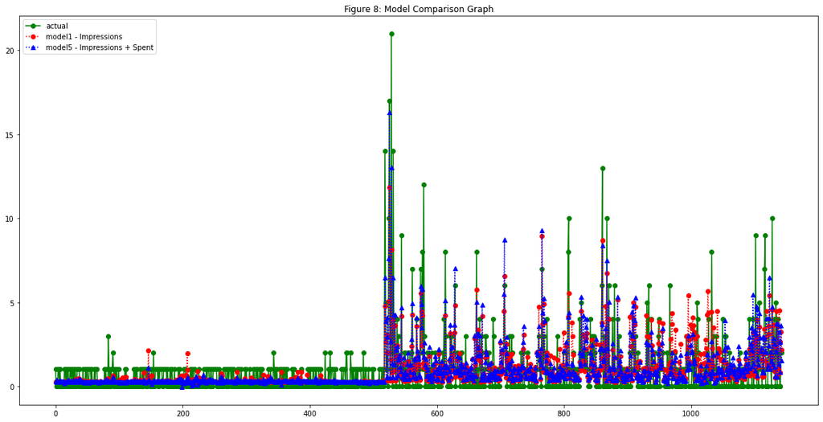

```python
# plot model 1 and model 5 in one graph:

# get fitted values of each model:
y_model1 = model1.fittedvalues
y_model5 = model5.fittedvalues

# plot actal observations, model 1 and model 4 in one graph:
plt.figure(figsize=(20,10))
plt.plot(df['Conversions'], "g-o",label='actual')
plt.plot(y_model1,"r:o",label='model1 - Impressions')
plt.plot(y_model5,"b:^",label='model5 - Impressions + Spent')
plt.legend(loc = 'upper left')
plt.title('Figure 8: Model Comparison Graph')
```